# Pemodelan ARIMA - Data Kurs JISDOR USD/IDR

Keira

2026-09-30

# 1 Packages

```r
library(ggplot2)
library(tseries)
library(MASS)
library(forecast)
library(TSA)
library(TTR)
library(lmtest)
library(rio)
```

# 2 Impor Data

Data: kurs JISDOR (USD/IDR) harian yang sudah dilengkapi (*forward fill*) menjadi deret kalender penuh, 26 Agustus 2024 – 24 Agustus 2026 (729 observasi).

```r
data_kurs <- import("Kurs_JISDOR_Lengkap_ForwardFill.xlsx", sheet = "Kurs JISDOR Lengkap")
names(data_kurs)[names(data_kurs) == "Kurs (IDR)"] <- "Kurs"
data_kurs$Periode <- 1:nrow(data_kurs)
head(data_kurs)
```

```
#>   NO    Tanggal  Kurs                 Keterangan Periode
#> 1  1 2024-08-26 15380                  Data Asli       1
#> 2  2 2024-08-27 15509                  Data Asli       2
#> 3  3 2024-08-28 15476                  Data Asli       3
#> 4  4 2024-08-29 15409                  Data Asli       4
#> 5  5 2024-08-30 15473                  Data Asli       5
#> 6  6 2024-08-31 15473 Akhir Pekan (Forward Fill)       6
```

Data dibagi menjadi data latih dan data uji dengan proporsi 80:20.

```r
n <- nrow(data_kurs)
n_train <- floor(0.8 * n)
n_test  <- n - n_train

training <- data_kurs[1:n_train, ]
testing  <- data_kurs[(n_train+1):n, ]

train.ts <- ts(training$Kurs)
test.ts  <- ts(testing$Kurs)
datakurs.ts <- ts(data_kurs$Kurs)

c(n = n, n_train = n_train, n_test = n_test)
```

```
#>       n n_train  n_test
#>     729     583     146
```

> **Interpretasi:** Dari 729 observasi, 583 data pertama menjadi data latih dan 146 data terakhir menjadi data uji.

# 3 Eksplorasi Data

## 3.1 Plot Data Penuh

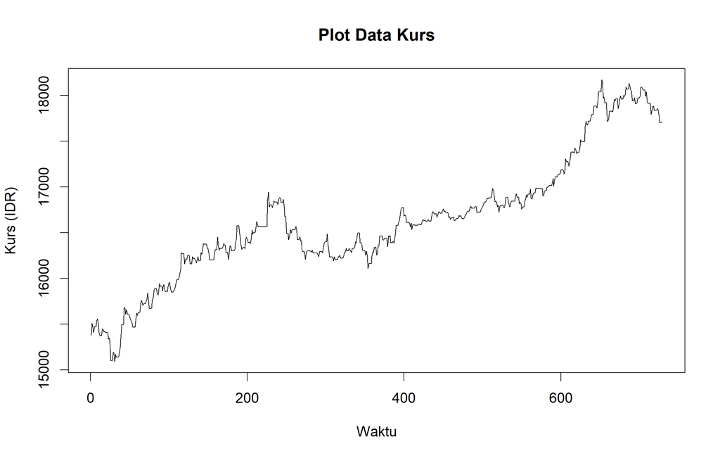

```r
plot.ts(datakurs.ts, lty = 1, xlab = "Waktu", ylab = "Kurs (IDR)", main = "Plot Data Kurs")
```

## 3.2 Plot Data Latih

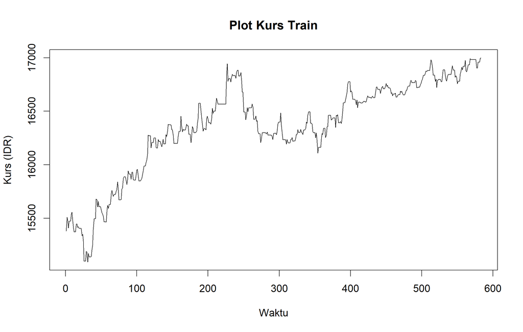

```r
plot.ts(train.ts, lty = 1, xlab = "Waktu", ylab = "Kurs (IDR)", main = "Plot Kurs Train")
```

## 3.3 Plot Data Uji

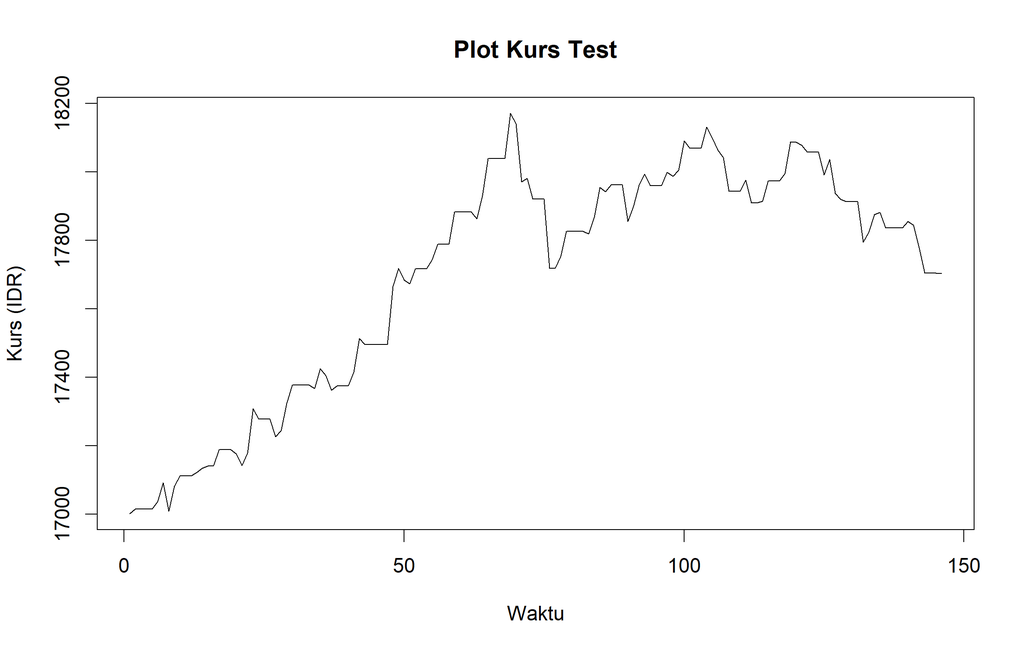

```r
plot.ts(test.ts, lty = 1, xlab = "Waktu", ylab = "Kurs (IDR)", main = "Plot Kurs Test")
```

> **Interpretasi:** Kurs USD/IDR bergerak pada rentang sekitar Rp15.092 – Rp16.999 dengan pola naik-turun yang tidak berputar di sekitar satu nilai tengah tetap (ciri *random walk* pada data finansial). Data uji berada di level yang lebih tinggi (mulai Rp17.002) daripada akhir data latih (Rp16.999) dan terus naik hingga sekitar Rp18.171. Secara visual data **belum stasioner dalam rataan**; hal ini dikonfirmasi lewat ACF dan uji ADF berikut.

# 4 Uji Stasioneritas Data

## 4.1 Plot ACF

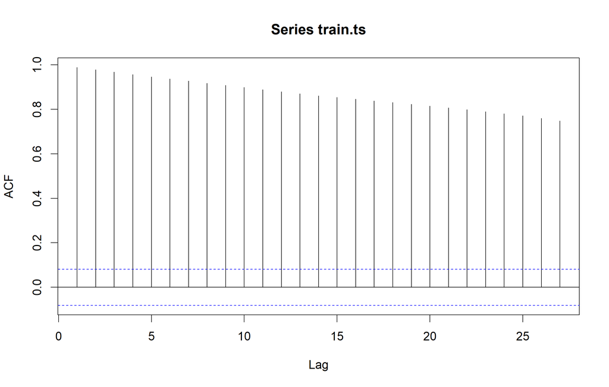

```r
acf(train.ts)
```

> **Interpretasi:** ACF sangat tinggi (0,989 di lag 1) dan meluruh sangat lambat (*tails off*), semua lag awal jauh di luar batas signifikansi. Ini indikasi kuat data **tidak stasioner dalam rataan**.

## 4.2 Uji ADF

```r
tseries::adf.test(train.ts)
```

```
#>
#>  Augmented Dickey-Fuller Test
#>
#> data:  train.ts
#> Dickey-Fuller = -2.3178, Lag order = 8, p-value = 0.4438
#> alternative hypothesis: stationary
```

$H_0$: data tidak stasioner dalam rataan; $H_1$: data stasioner dalam rataan.

> **Interpretasi:** Statistik Dickey-Fuller = -2,318 dengan *p-value* = 0,4438 (> 0,05), sehingga **gagal tolak $H_0$**: data tidak stasioner dalam rataan. Konsisten dengan plot deret waktu dan ACF.

## 4.3 Plot Box-Cox

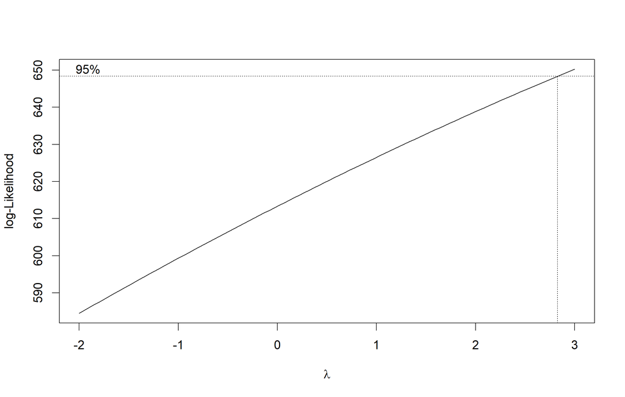

```r
index <- seq(1:length(train.ts))

# Box-Cox
bc <- boxcox(train.ts ~ index, lambda = seq(-2, 3, by = 0.1))
```

```r
# Nilai lambda optimum
lambda_opt <- bc$x[which.max(bc$y)]
lambda_opt
```

```
#> [1] 3
```

```r
# Selang kepercayaan 95% untuk lambda
ci_lambda <- bc$x[bc$y > max(bc$y) - 0.5 * qchisq(0.95, df = 1)]

# Batas bawah dan batas atas
ci_lower <- min(ci_lambda)
ci_upper <- max(ci_lambda)

c(Batas_Bawah = ci_lower, Batas_Atas = ci_upper)
```

```
#> Batas_Bawah  Batas_Atas
#>    2.848485    3.000000
```

# 5 Penanganan Ketidakstasioneran Data

## 5.1 Differencing Pertama

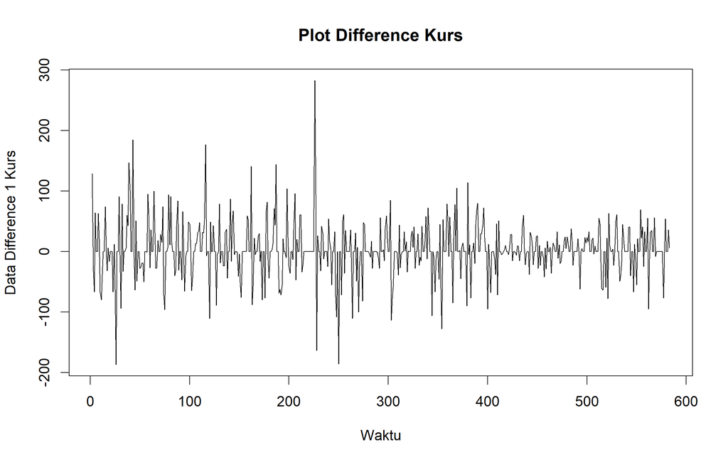

```r
train.diff <- diff(train.ts, differences = 1)

plot.ts(train.diff, lty = 1, xlab = "Waktu", ylab = "Data Difference 1 Kurs",
        main = "Plot Difference Kurs")
```

> **Interpretasi:** Setelah differencing satu kali, data berfluktuasi di sekitar satu nilai tengah (rata-rata sekitar 2,8 rupiah per hari) tanpa tren, sehingga indikasi awal data sudah stasioner dalam rataan.

## 5.2 Plot ACF Setelah Differencing

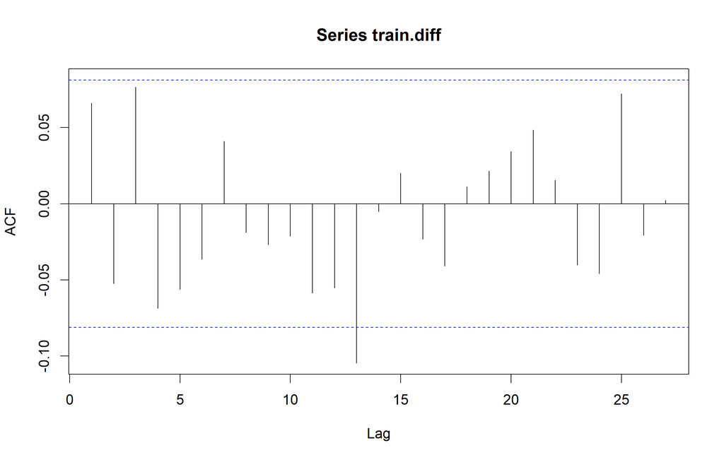

```r
acf(train.diff)
```

> **Interpretasi:** ACF hampir seluruhnya berada dalam batas signifikansi. Hanya lag 13 yang sedikit keluar batas, yang wajar sebagai kebetulan statistik dari banyak lag yang diuji. Ketidakstasioneran rataan sudah teratasi.

## 5.3 Uji ADF Setelah Differencing

```r
tseries::adf.test(train.diff)
```

[output not shown]

> **Interpretasi:** *p-value* = 0,01 (< 0,05), sehingga **tolak $H_0$**: data hasil differencing stasioner dalam rataan. Sejalan dengan plot dan ACF.

## 5.4 Cek Ulang Ragam Setelah Differencing

Data hasil differencing memuat nilai negatif dan nol, padahal `boxcox()` hanya menerima data positif. Sesuai panduan, data digeser dengan konstanta agar nilai minimumnya menjadi 1.

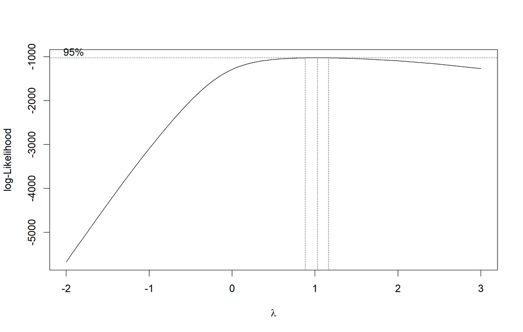

```r
# 1. Sesuaikan panjang index karena differencing menghilangkan 1 observasi awal
index_diff <- seq(1:length(train.diff))

# 2. Cek nilai negatif/nol; jika ada, tambahkan konstanta agar minimum > 0
min_val <- min(train.diff)

if (min_val <= 0) {
  c <- abs(min_val) + 1
  train.diff_shifted <- train.diff + c
} else {
  train.diff_shifted <- train.diff
}

# 3. Plot Box-Cox pada data yang sudah di-shift
bc_diff <- boxcox(train.diff_shifted ~ index_diff, lambda = seq(-2, 3, by = 0.1))
```

```r
# 4. Nilai lambda optimum
lambda_opt_diff <- bc_diff$x[which.max(bc_diff$y)]
print(paste("Lambda optimum setelah diff:", lambda_opt_diff))
```

```
#> [1] "Lambda optimum setelah diff: 1.03030303030303"
```

```r
# 5. Selang kepercayaan 95% untuk lambda
ci_lambda_diff <- bc_diff$x[bc_diff$y > max(bc_diff$y) - 0.5 * qchisq(0.95, df = 1)]

ci_lower_diff <- min(ci_lambda_diff)
ci_upper_diff <- max(ci_lambda_diff)

c(Batas_Bawah = ci_lower_diff, Batas_Atas = ci_upper_diff)
```

```
#> Batas_Bawah  Batas_Atas
#>   0.9292929   1.1313131
```

> **Interpretasi:** Selang **memuat 1**, sehingga ragam data hasil differencing sudah stasioner dan **tidak perlu transformasi Box-Cox tambahan**.

# 6 Identifikasi Model

## 6.1 Plot ACF dan PACF

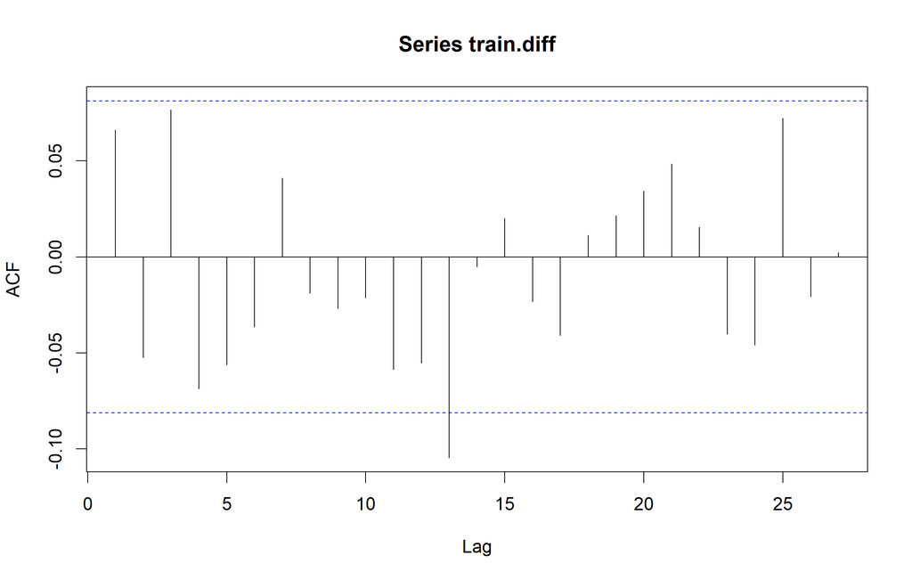

```r
acf(train.diff)
```

> **Interpretasi ACF:** Tidak ada lag awal yang konsisten signifikan (*cuts off* sejak lag 1), menunjukkan komponen MA berorde rendah (0 atau 1).

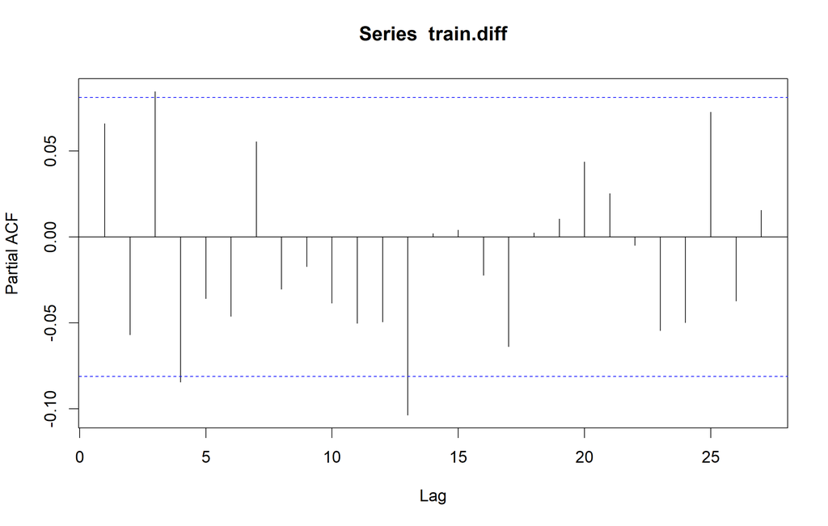

```r
pacf(train.diff)
```

> **Interpretasi PACF:** Juga *cuts off* sejak awal; lag 3 dan lag 4 hanya sedikit melewati batas, sehingga komponen AR berorde rendah (0 atau 1).

## 6.2 Plot EACF

```r
eacf(train.diff)
```

```
#> AR/MA
#>   0 1 2 3 4 5 6 7 8 9 10 11 12 13
#> 0 o o o o o o o o o o o  o  x  o
#> 1 x o o o o o o o o o o  o  x  o
#> 2 x x o x o o o o o o o  o  x  o
#> 3 x x x o o o o o o o o  o  x  o
#> 4 x x x x o o o o o o o  o  x  o
#> 5 x x x x o o o o o o o  o  x  o
#> 6 x x o x o x o o o o o  o  x  o
#> 7 x x x x x o x o o o o  o  x  o
```

> **Interpretasi:** Karena ACF dan PACF sama-sama *cuts off* cepat, diajukan model tentatif orde rendah: **ARIMA(0,1,1)**, **ARIMA(1,1,0)**, **ARIMA(1,1,1)**, dan **ARIMA(2,1,2)**.

# 7 Pendugaan Parameter Model Tentatif

Sesuai panduan, model dibangun pada data hasil differencing (`train.diff`) dengan orde d = 0, yang setara dengan ARIMA(p,1,q) pada data asli (dengan tambahan konstanta/*intercept* sebagai rata-rata selisih).

## 7.1 ARIMA(0,1,1)

```r
model1.da <- Arima(train.diff, order = c(0,0,1), method = "ML")
summary(model1.da)
```

```
#> Series: train.diff
#> ARIMA(0,0,1) with non-zero mean
#>
#> Coefficients:
#>          ma1    mean
#>       0.0771  2.7887
#> s.e.  0.0451  1.9609
#>
#> sigma^2 = 1936:  log likelihood = -3027.21
#> AIC=6060.43   AICc=6060.47   BIC=6073.53
#>
#> Training set error measures:
#>                        ME     RMSE      MAE MPE MAPE      MASE         ACF1
#> Training set -0.006920518 43.92373 27.76836 NaN  Inf 0.6922728 -0.006185363
```

```r
lmtest::coeftest(model1.da)
```

```
#>
#> z test of coefficients:
#>
#>           Estimate Std. Error z value Pr(>|z|)
#> ma1       0.077112   0.045069  1.7110  0.08708 .
#> intercept 2.788734   1.960875  1.4222  0.15497
#> ---
#> Signif. codes:  0 '***' 0.001 '**' 0.01 '*' 0.05 '.' 0.1 ' ' 1
```

> **Interpretasi:** AIC ≈ 6060,4; ma1 ≈ 0,077 dengan *p-value* ≈ 0,088 (> 0,05) sehingga **tidak signifikan**.

## 7.2 ARIMA(1,1,0)

```r
model2.da <- Arima(train.diff, order = c(1,0,0), method = "ML")
summary(model2.da)
```

```
#> Series: train.diff
#> ARIMA(1,0,0) with non-zero mean
#>
#> Coefficients:
#>          ar1    mean
#>       0.0669  2.7883
#> s.e.  0.0416  1.9516
#>
#> sigma^2 = 1937:  log likelihood = -3027.4
#> AIC=6060.79   AICc=6060.84   BIC=6073.89
#>
#> Training set error measures:
#>                        ME     RMSE      MAE MPE MAPE      MASE        ACF1
#> Training set -0.006230143 43.93763 27.73107 NaN  Inf 0.6913431 0.002976553
```

```r
lmtest::coeftest(model2.da)
```

```
#>
#> z test of coefficients:
#>
#>           Estimate Std. Error z value Pr(>|z|)
#> ar1       0.066879   0.041616  1.6070   0.1080
#> intercept 2.788339   1.951592  1.4288   0.1531
```

> **Interpretasi:** AIC ≈ 6060,8; ar1 ≈ 0,067 dengan *p-value* ≈ 0,108 **tidak signifikan**.

## 7.3 ARIMA(1,1,1)

```r
model3.da <- Arima(train.diff, order = c(1,0,1), method = "ML")
summary(model3.da)
```

```
#> Series: train.diff
#> ARIMA(1,0,1) with non-zero mean
#>
#> Coefficients:
#>           ar1     ma1    mean
#>       -0.6832  0.7822  2.7747
#> s.e.   0.1115  0.0935  1.9151
#>
#> sigma^2 = 1914:  log likelihood = -3023.39
#> AIC=6054.79   AICc=6054.86   BIC=6072.25
#>
#> Training set error measures:
#>                       ME     RMSE      MAE MPE MAPE      MASE        ACF1
#> Training set 0.004473806 43.63481 28.12792 NaN  Inf 0.7012366 -0.01687838
```

```r
lmtest::coeftest(model3.da)
```

```
#>
#> z test of coefficients:
#>
#>            Estimate Std. Error z value  Pr(>|z|)
#> ar1       -0.683153   0.111511 -6.1263 8.994e-10 ***
#> ma1        0.782216   0.093506  8.3654 < 2.2e-16 ***
#> intercept  2.774679   1.915070  1.4489    0.1474
#> ---
#> Signif. codes:  0 '***' 0.001 '**' 0.01 '*' 0.05 '.' 0.1 ' ' 1
```

## 7.4 ARIMA(2,1,2)

```r
model4.da <- Arima(train.diff, order = c(2,0,2), method = "ML")
summary(model4.da)
```

```
#> Series: train.diff
#> ARIMA(2,0,2) with non-zero mean
#>
#> Coefficients:
#>          ar1     ar2      ma1      ma2    mean
#>       0.2582  0.5997  -0.1792  -0.7243  2.7733
#> s.e.  0.1230  0.1190   0.1046   0.1009  1.2392
#>
#> sigma^2 = 1909:  log likelihood = -3021.74
#> AIC=6055.48   AICc=6055.62   BIC=6081.68
#>
#> Training set error measures:
#>                       ME     RMSE      MAE MPE MAPE      MASE         ACF1
#> Training set -0.01376673 43.50885 28.12649 NaN  Inf 0.7012011 -0.002234562
```

```r
lmtest::coeftest(model4.da)
```

```
#>
#> z test of coefficients:
#>
#>           Estimate Std. Error z value  Pr(>|z|)
#> ar1        0.25821    0.12297  2.0997   0.03575 *
#> ar2        0.59973    0.11897  5.0410 4.631e-07 ***
#> ma1       -0.17916    0.10455 -1.7136   0.08661 .
#> ma2       -0.72435    0.10090 -7.1787 7.037e-13 ***
#> intercept  2.77335    1.23924  2.2379   0.02522 *
#> ---
#> Signif. codes:  0 '***' 0.001 '**' 0.01 '*' 0.05 '.' 0.1 ' ' 1
```

# 8 Ringkasan AIC

```r
model_tentatif <- data.frame(
  Model = c("ARIMA(0,1,1)", "ARIMA(1,1,0)", "ARIMA(1,1,1)", "ARIMA(2,1,2)"),
  AIC = c(AIC(model1.da), AIC(model2.da), AIC(model3.da), AIC(model4.da)),
  BIC = c(BIC(model1.da), BIC(model2.da), BIC(model3.da), BIC(model4.da))
)
model_tentatif[order(model_tentatif$AIC), ]
```

```
#>          Model      AIC      BIC
#> 3 ARIMA(1,1,1) 6054.786 6072.252
#> 4 ARIMA(2,1,2) 6055.477 6081.676
#> 1 ARIMA(0,1,1) 6060.428 6073.527
#> 2 ARIMA(1,1,0) 6060.795 6073.894
```

> **Interpretasi:** ARIMA(1,1,1) memiliki AIC terkecil (≈ 6054,8) dan merupakan satu-satunya model dengan parameter AR/MA yang seluruhnya signifikan, sehingga dipilih sebagai **model terbaik**. ARIMA(1,1,1) juga memiliki BIC terkecil (≈ 6072,3 dibanding ≈ 6073,5 untuk ARIMA(0,1,1)), meskipun selisihnya tipis.

# 9 Analisis Sisaan

Sisaan model terbaik ARIMA(1,1,1) diperiksa asumsinya.

## 9.1 Eksplorasi Sisaan

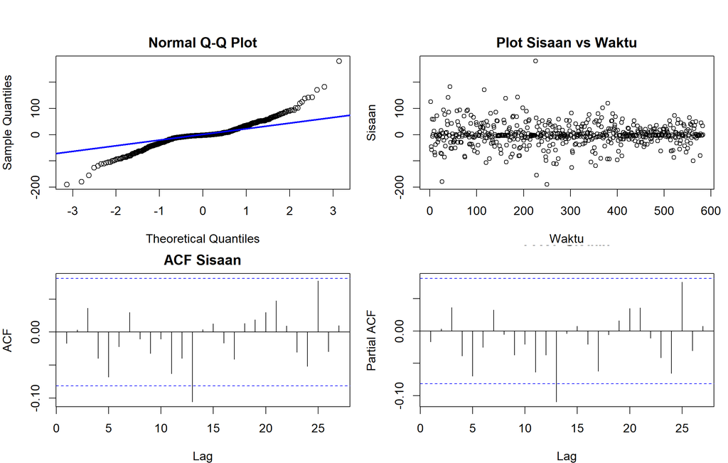

```r
sisaan.da <- model3.da$residuals

par(mfrow = c(2,2), mar = c(4,4,2,1), oma = c(0,0,2,0))

# Q-Q Plot
qqnorm(sisaan.da, main = "Normal Q-Q Plot")
qqline(sisaan.da, col = "blue", lwd = 2)

# Plot Sisaan vs Waktu
plot(sisaan.da, type = "p", main = "Plot Sisaan vs Waktu", xlab = "Waktu", ylab = "Sisaan")

# ACF
acf(sisaan.da, main = "ACF Sisaan")

# PACF
pacf(sisaan.da, main = "PACF Sisaan")
```

```r
par(mfrow = c(1,1))
```

> **Interpretasi:** Titik Q-Q mengikuti garis di bagian tengah tetapi menyimpang di kedua ujung (ekor tebal, kurtosis berlebih), ciri umum data finansial. Plot sisaan vs waktu tersebar acak di sekitar nol, dan ACF/PACF sisaan tidak menunjukkan lonjakan berarti, sehingga sisaan secara visual saling bebas.

## 9.2 Uji Formal

```r
# 1) Sisaan menyebar normal
ks.test(sisaan.da, "pnorm", mean(sisaan.da), sd(sisaan.da))
```

```
#>
#>  Asymptotic one-sample Kolmogorov-Smirnov test
#>
#> data:  sisaan.da
#> D = 0.13468, p-value = 1.355e-09
#> alternative hypothesis: two-sided
```

$H_0$: sisaan menyebar normal.

> **Interpretasi:** *p-value* ≈ 1e-09 (< 0,05) → **tolak $H_0$**, sisaan tidak menyebar normal (ekor tebal/leptokurtik).

```r
# 2) Sisaan saling bebas / tidak ada autokorelasi
Box.test(sisaan.da, type = "Ljung")
```

```
#>
#>  Box-Ljung test
#>
#> data:  sisaan.da
#> X-squared = 0.16666, df = 1, p-value = 0.6831
```

$H_0$: sisaan saling bebas.

> **Interpretasi:** *p-value* ≈ 0,683 (> 0,05) → **gagal tolak $H_0$**, sisaan saling bebas. Asumsi **terpenuhi**.

```r
# 3) Sisaan homogen
Box.test((sisaan.da)^2, type = "Ljung")
```

```
#>
#>  Box-Ljung test
#>
#> data:  (sisaan.da)^2
#> X-squared = 0.74863, df = 1, p-value = 0.3869
```

$H_0$: ragam sisaan homogen.

> **Interpretasi:** *p-value* ≈ 0,387 (> 0,05) → **gagal tolak $H_0$**, ragam sisaan homogen (tidak ada efek ARCH pada lag ini). Asumsi **terpenuhi**.

```r
# 4) Nilai tengah sisaan sama dengan nol
t.test(sisaan.da, mu = 0, conf.level = 0.95)
```

```
#>
#>  One Sample t-test
#>
#> data:  sisaan.da
#> t = 0.0024713, df = 581, p-value = 0.998
#> alternative hypothesis: true mean is not equal to 0
#> 95 percent confidence interval:
#>  -3.551011  3.559958
#> sample estimates:
#>   mean of x
#> 0.004473806
```

$H_0$: nilai tengah sisaan = 0.

> **Interpretasi:** *p-value* ≈ 0,998 (> 0,05) → **gagal tolak $H_0$**, nilai tengah sisaan sama dengan nol. Asumsi **terpenuhi**.

> **Kesimpulan sisaan:** 3 dari 4 asumsi terpenuhi (kebebasan, kehomogenan ragam, nilai tengah nol); hanya normalitas yang tidak terpenuhi. Ini keterbatasan yang wajar pada data kurs harian, dan terutama memengaruhi selang kepercayaan ramalan, bukan ramalan titik.

# 10 Overfitting

Orde AR dan MA model terbaik ARIMA(1,1,1) dinaikkan satu tingkat.

## 10.1 ARIMA(2,1,1)

```r
model1a.da <- Arima(train.diff, order = c(2,0,1), method = "ML")
summary(model1a.da)
```

```
#> Series: train.diff
#> ARIMA(2,0,1) with non-zero mean
#>
#> Coefficients:
#>           ar1      ar2     ma1    mean
#>       -0.6593  -0.0328  0.7421  2.7805
#> s.e.   0.1252   0.0477  0.1185  1.8615
#>
#> sigma^2 = 1916:  log likelihood = -3023.17
#> AIC=6056.33   AICc=6056.44   BIC=6078.16
#>
#> Training set error measures:
#>                       ME     RMSE      MAE MPE MAPE      MASE         ACF1
#> Training set -0.00127498 43.61758 28.19839 NaN  Inf 0.7029936 0.0004169807
```

```r
lmtest::coeftest(model1a.da)
```

```
#>
#> z test of coefficients:
#>
#>            Estimate Std. Error z value  Pr(>|z|)
#> ar1       -0.659301   0.125150 -5.2681 1.379e-07 ***
#> ar2       -0.032775   0.047710 -0.6870    0.4921
#> ma1        0.742128   0.118543  6.2604 3.840e-10 ***
#> intercept  2.780484   1.861529  1.4937    0.1353
#> ---
#> Signif. codes:  0 '***' 0.001 '**' 0.01 '*' 0.05 '.' 0.1 ' ' 1
```

## 10.2 ARIMA(1,1,2)

```r
model1b.da <- Arima(train.diff, order = c(1,0,2), method = "ML")
summary(model1b.da)
```

```
#> Series: train.diff
#> ARIMA(1,0,2) with non-zero mean
#>
#> Coefficients:
#>           ar1     ma1      ma2    mean
#>       -0.6252  0.7099  -0.0320  2.7765
#> s.e.   0.1557  0.1579   0.0511  1.8667
#>
#> sigma^2 = 1916:  log likelihood = -3023.19
#> AIC=6056.39   AICc=6056.49   BIC=6078.22
#>
#> Training set error measures:
#>                       ME     RMSE     MAE MPE MAPE      MASE         ACF1
#> Training set 0.002563647 43.61964 28.1851 NaN  Inf 0.7026623 -0.001591201
```

```r
lmtest::coeftest(model1b.da)
```

```
#>
#> z test of coefficients:
#>
#>            Estimate Std. Error z value  Pr(>|z|)
#> ar1       -0.625213   0.155729 -4.0147 5.951e-05 ***
#> ma1        0.709881   0.157936  4.4947 6.966e-06 ***
#> ma2       -0.032049   0.051069 -0.6276    0.5303
#> intercept  2.776510   1.866662  1.4874    0.1369
#> ---
#> Signif. codes:  0 '***' 0.001 '**' 0.01 '*' 0.05 '.' 0.1 ' ' 1
```

```r
overfitting <- data.frame(
  Model = c("ARIMA(1,1,1)", "ARIMA(2,1,1)", "ARIMA(1,1,2)"),
  AIC   = c(AIC(model3.da), AIC(model1a.da), AIC(model1b.da)),
  BIC   = c(BIC(model3.da), BIC(model1a.da), BIC(model1b.da))
)
overfitting
```

```
#>          Model      AIC      BIC
#> 1 ARIMA(1,1,1) 6054.786 6072.252
#> 2 ARIMA(2,1,1) 6056.332 6078.164
#> 3 ARIMA(1,1,2) 6056.386 6078.218
```

> **Interpretasi:** Pada ARIMA(2,1,1) parameter tambahan ar2 tidak signifikan dan AIC lebih besar. Pada ARIMA(1,1,2) parameter ma2 tidak signifikan dan AIC juga lebih besar. Karena tidak ada perbaikan, **ARIMA(1,1,1) tetap dipertahankan** sebagai model terbaik.

# 11 Model Terbaik: ARIMA(1,1,1)

```r
model_terbaik <- model3.da
summary(model_terbaik)
```

```
#> Series: train.diff
#> ARIMA(1,0,1) with non-zero mean
#>
#> Coefficients:
#>           ar1     ma1    mean
#>       -0.6832  0.7822  2.7747
#> s.e.   0.1115  0.0935  1.9151
#>
#> sigma^2 = 1914:  log likelihood = -3023.39
#> AIC=6054.79   AICc=6054.86   BIC=6072.25
#>
#> Training set error measures:
#>                       ME     RMSE      MAE MPE MAPE      MASE        ACF1
#> Training set 0.004473806 43.63481 28.12792 NaN  Inf 0.7012366 -0.01687838
```

```r
lmtest::coeftest(model_terbaik)
```

```
#>
#> z test of coefficients:
#>
#>            Estimate Std. Error z value  Pr(>|z|)
#> ar1       -0.683153   0.111511 -6.1263 8.994e-10 ***
#> ma1        0.782216   0.093506  8.3654 < 2.2e-16 ***
#> intercept  2.774679   1.915070  1.4489    0.1474
#> ---
#> Signif. codes:  0 '***' 0.001 '**' 0.01 '*' 0.05 '.' 0.1 ' ' 1
```

> **Interpretasi:** Model: $\hat{Z}_t = 2{,}77 - 0{,}68\,Z_{t-1} + \varepsilon_t + 0{,}782\,\varepsilon_{t-1}$, dengan $Z_t = Y_t - Y_{t-1}$ (selisih kurs harian) dan $\sigma^2 \approx 1913.86$.

# 12 Peramalan

```r
ramalan.da <- forecast::forecast(model_terbaik, h = length(test.ts))
```

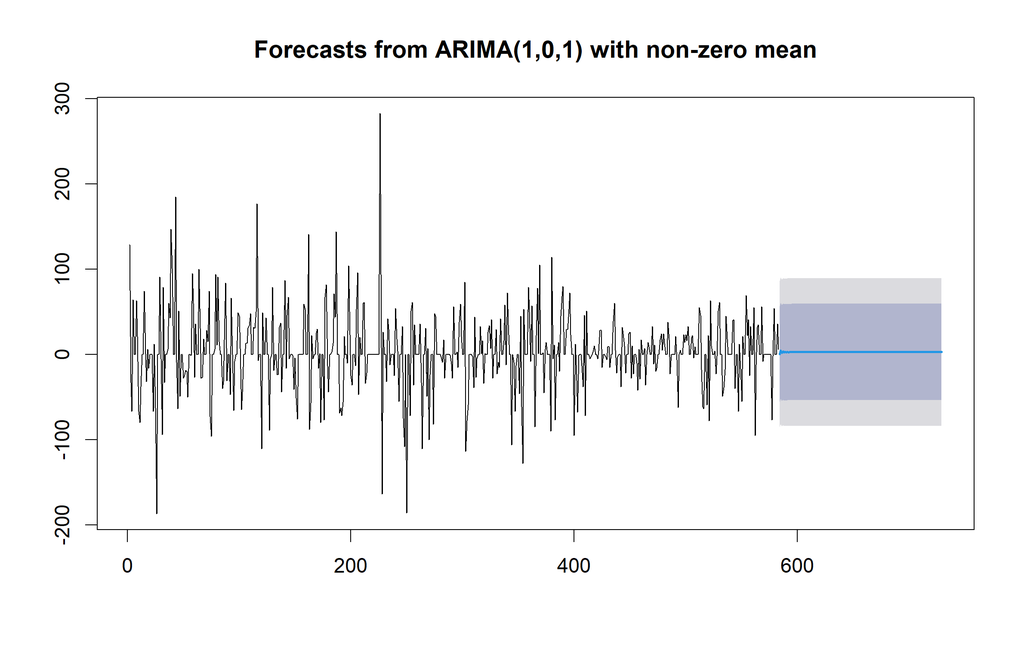

```r
data.ramalan.da <- ramalan.da$mean
plot(ramalan.da)
```

```r
# Inverse differencing
pt_akhir_train <- tail(train.ts, 1)

forecast <- diffinv(data.ramalan.da, differences = 1, xi = pt_akhir_train)
hasil <- forecast[-1]   # buang titik awal (nilai terakhir data latih)

# Bandingkan aktual vs forecast
perbandingan.da <- cbind(
  Aktual   = test.ts,
  Forecast = hasil
)

print(head(perbandingan.da, 10))
```

```
#> Time Series:
#> Start = 1
#> End = 10
#> Frequency = 1
#>    Aktual Forecast
#>  1  17002 16999.64
#>  2  17015 17003.87
#>  3  17015 17005.65
#>  4  17015 17009.11
#>  5  17015 17011.41
#>  6  17037 17014.51
#>  7  17092 17017.06
#>  8  17009 17019.99
#>  9  17082 17022.66
#> 10  17112 17025.50
```

```r
# Hitung akurasi
akurasi_test <- accuracy(hasil, test.ts)
akurasi_test
```

```
#>                ME    RMSE      MAE      MPE   MAPE      ACF1 Theil's U
#> Test set 496.8347 556.587 496.9852 2.781915 2.7828 0.9656269  11.25181
```

> **Interpretasi:** Pada 146 hari data uji diperoleh RMSE ≈ 556,6; MAE ≈ 496,9; dan MAPE ≈ 2,78%. MAPE < 3% menunjukkan ketepatan yang cukup baik untuk periode peramalan selama 146 hari, dan galat membesar seiring bertambahnya rentang waktu.

```r
# Pembanding: ramalan naif (kurs = nilai terakhir data latih)
naif <- rep(as.numeric(pt_akhir_train), length(test.ts))
accuracy(naif, test.ts)
```

```
#>             ME     RMSE   MAE     MPE    MAPE      ACF1 Theil's U
#> Test set 699.5 776.3843 699.5 3.91702 3.91702 0.9747546   15.6967
```

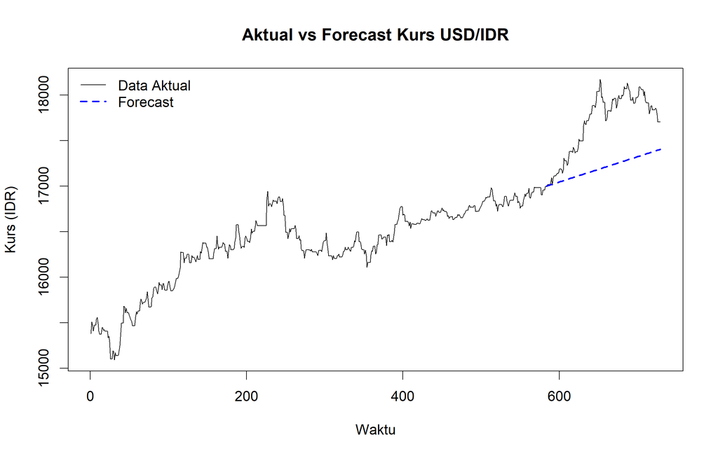

```r
# Plot data aktual vs forecast
ts.plot(datakurs.ts, col = "black", lty = 1, xlab = "Waktu", ylab = "Kurs (IDR)",
        main = "Aktual vs Forecast Kurs USD/IDR")
lines((n_train+1):(n_train+length(hasil)), hasil, col = "blue", lty = 2, lwd = 2)
legend("topleft", legend = c("Data Aktual", "Forecast"),
       col = c("black", "blue"), lty = c(1,2), lwd = c(1,2), bty = "n")
```

> **Interpretasi:** Garis ramalan (biru putus-putus) naik landai dan berada di bawah data aktual pada sebagian besar periode uji, yang terlihat sebagai jarak yang melebar ke akhir periode.

# 13 Kesimpulan